# Tree Based Methods Workshop

## Conditional Trees

In all the models so far, trees were built by selecting for each split in the tree the variable that minimizes error metric (e.g. classification error or regression RSS). This approach is inherently biased towards selecting categorical variables with many splits or many missing values, and it tends to prefer continous variables over categorical ones. Conditional trees tackle this problem by employing significance test procedure to select variables to split the tree. At each tree node, significance is calculated for each potential variables, and the one with the lowest p value is selected for split. You can probably already understand that this comes at a significant computational cost, and fiting a tree takes more time.

The only parameter to tune for conditional trees is number of randomly selected variables `mtry`.

```r
# set up a 3-fold cross validation
ctrl <- trainControl(method = "cv",  number = 5)

# parameter grid search
hyper_grid <- expand.grid(
  mtry = seq(1050, 1250, by = 50)
)

# total number of combinations
nrow(hyper_grid)

# build models without CV or importance calculation
crf_tree <- caret::train(
  x = tpm_train[,tfs],
  y = tpm_train[,gene],
  method = "cforest",
  trControl = ctrl,
  tuneGrid = hyper_grid
)

# save
grid_res <- crf_tree$results
fwrite(grid_res, file = sprintf("data/hypergrid.crf.%s.csv",gene))
```

Visualize results of grid search.

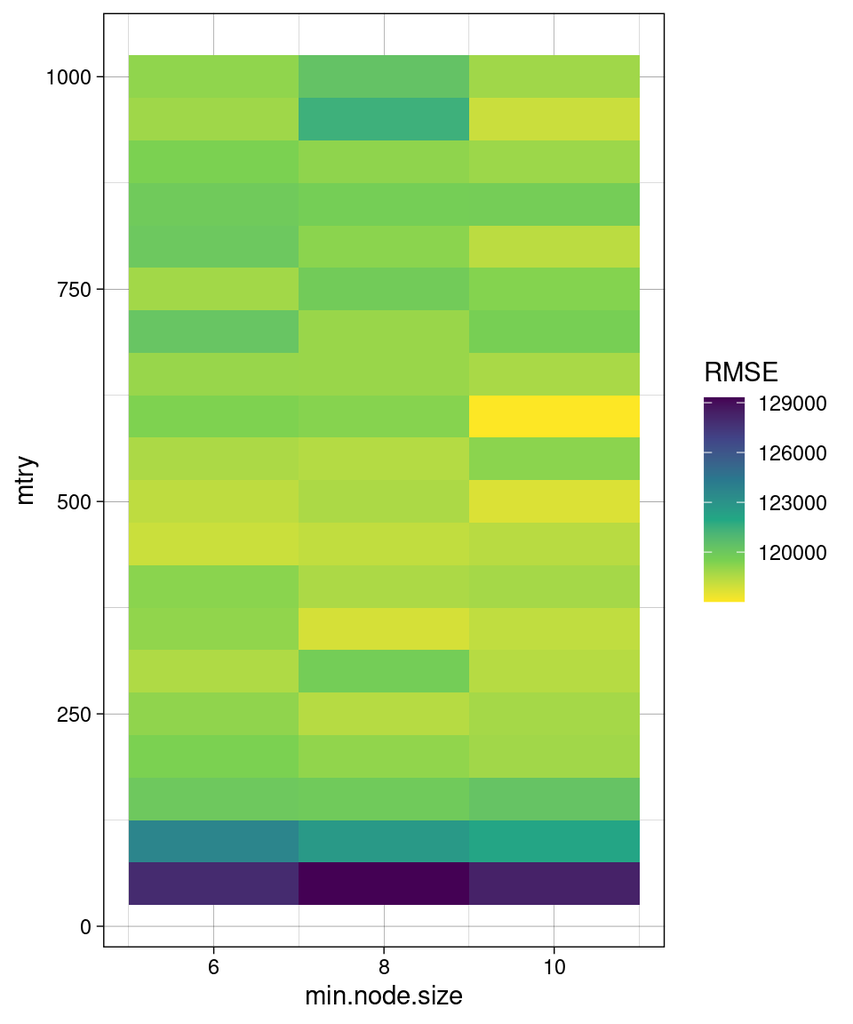

```r
# load grid search results
grid_res <- fread(sprintf("data/hypergrid.rf.%s.csv",gene))

# plot
ggplot(grid_res, aes(min.node.size, mtry, fill = RMSE)) +
  geom_tile() + scale_fill_viridis_c(direction = -1)
```

```r
# top parameter combinations
grid_res[order(RMSE)][1:5]
```

| splitrule | mtry | min.node.size | RMSE | Rsquared | MAE | RMSESD | RsquaredSD | MAESD |
| --- | --- | --- | --- | --- | --- | --- | --- | --- |
| variance | 600 | 10 | 117010.0 | 0.8208543 | 70483.30 | 15886.88 | 0.02950449 | 9690.812 |
| variance | 500 | 10 | 117717.8 | 0.8182241 | 70924.26 | 16722.78 | 0.03219688 | 10456.549 |
| variance | 350 | 8 | 117832.4 | 0.8198559 | 70968.34 | 17399.84 | 0.03365443 | 10692.650 |
| variance | 450 | 6 | 118043.0 | 0.8174429 | 70761.52 | 17918.07 | 0.03561291 | 10882.650 |
| variance | 950 | 10 | 118054.4 | 0.8154179 | 70924.67 | 18094.89 | 0.03749453 | 11120.839 |

**TASK:** Select best parameters obtained from grid search and build the model.

```r
require(caret)

# set up a 10-fold cross validation
ctrl <- trainControl(method = "cv",  number = 10)

# parameter grid with fixed best values
i <- which.min(grid_res$RMSE)
tuned_grid <- expand.grid(
  mtry = grid_res$mtry[i]
)

# CV rf model with importance calculation
crf_tree <- caret::train(
  x = tpm_train[,tfs],
  y = tpm_train[,gene],
  method = "cforest",
  trControl = ctrl,
  tuneGrid = tuned_grid
)

# assess results
crf_tree
```

**TASK:** Extract variable importance for model.

```r
# most important variables
varimp <- varImp(rf_tree)
plot(varimp, 30)
varimp_dt <- as.data.table(varimp$importance, keep.rownames = "Variable")[order(-Overall)]
head(varimp_dt)
```

**TASK:** Prediction using Random Forest with conditional trees.

```r
# predict
pred <- predict(crf_tree, tpm_test[, tfs])
RMSE(pred = pred, obs = tpm_test[, gene])

pred_df <- data.frame(predicted=pred, actual=tpm_test[, gene])
ggplot(pred_df, aes(predicted, actual)) +
    geom_point() +
    geom_smooth(method='lm', formula=y~x)
```

## Boosting

Boosting is a group of methods that attempt to train predictors sequentially, each trying to correct its predecessor. Probably most commonly used is Gradient Boosting, which fits the next predictor to the residual errors made by the previous predictor.

Important parameters to tune for boosting are:

- `mstop` number of boosting iterations,
- `maxdepth` the maximum number of internal nodes between the root node and the terminal nodes,
- `nu` learning rate, scales the contribution of each tree

**QUESTION**: How will low or high `nu` value affect model performance?

If you set `nu` to a low value, such as 0.1, it will take more trees to fit the training data, but the predictions will usually generalize better.

```r
# set up cross validation
ctrl <- trainControl(method = "cv",  number = 5)

# parameter grid search
hyper_grid <- expand.grid(
  mstop = seq(100, 200, 50),
  maxdepth = seq(10, 30, 5),
  #nu = c(0.01, seq(0.1, 0.5, 0.1))
  nu = c(0.2, 0.3, 0.4)
)

# total number of combinations
nrow(hyper_grid)

# build models
bst_tree <- caret::train(
  x = tpm_train[,tfs],
  y = tpm_train[,gene],
  method = "bstTree",
  trControl = ctrl,
  tuneGrid = hyper_grid
)

# save
grid_res <- bst_tree$results
fwrite(grid_res, file = sprintf("data/hypergrid.bst.%s.csv",gene))
```

Visualize results of grid search.

```r
# load grid search results
grid_res <- fread(sprintf("data/hypergrid.bst.%s.csv",gene))
grid_res[,nu:=factor(nu)]
ggplot(grid_res, aes(mstop, nu, fill = RMSE)) +
  geom_tile() + scale_fill_viridis_c(direction = -1)

# top parameter combinations
grid_res[,nu:=as.numeric(nu)]
grid_res[order(RMSE)][1:5]
```

[output not shown]

**TASK:** Select best parameters obtained from grid search and build the model.

```r
# set up a 10-fold cross validation
ctrl <- trainControl(method = "cv",  number = 10)

# parameter grid with fixed best values
i <- which.min(grid_res$RMSE)
tuned_grid <- data.frame(
  mstop = grid_res$mstop[i],
  maxdepth = grid_res$maxdepth[i],
  nu = grid_res$nu[i]
)

# build a model
bst_tree <- caret::train(
  x = tpm_train[,tfs],
  y = tpm_train[,gene],
  method = "bstTree",
  trControl = ctrl,
  tuneGrid = tuned_grid
)
bst_tree
```

Extract variable importance for model.

```r
# most important variables
varimp <- varImp(bst_tree)
plot(varimp, 30)
varimp_dt <- as.data.table(varimp$importance, keep.rownames = "Variable")[order(-Overall)][]
head(varimp_dt)
```

Use Boosting model for prediction with test data.

```r
# predict
pred <- predict(bst_tree, tpm_test[, tfs])
RMSE(pred = pred, obs = tpm_test[, gene])

pred_df <- data.frame(predicted=pred, actual=tpm_test[, gene])
ggplot(pred_df, aes(predicted, actual)) +
    geom_point() +
    geom_smooth(method='lm', formula=y~x)
```

## Downstream analysis

The models described above are fit in the same way for other genes of interest. Here we will briefly inspect their overall performance.

Load pre-calculated model errors for different genes and order them by increasing RF RMSE.

```r
dt = fread("data/20220919112028.rmse.txt")
setnames(dt, c("genes","model","rmse"))
dt[, model:=factor(model, levels=c("decision_tree","bagging","random_forest","boosting"))]
dt[, genes:=factor(genes, levels=unique(dt[model=="random_forest"][order(-rmse)]$genes))]
setorder(dt,genes,rmse)
```

Random Forrest systematically outperforms single Decision Tree.

```r
ggplot(dt, aes(genes, rmse, color=model)) +
  geom_line(aes(group=model)) +
  geom_point() +
  theme(
    panel.grid.major.x = element_blank(),
    axis.ticks.length.x = unit(0,"mm")
  ) + coord_flip()
```

[output not shown]

Finally, we can use variable importance to prioritize genes for building a Gene Regrulatory Network. The choice of how many TFs to include in the network is a bit arbitrary at this point.

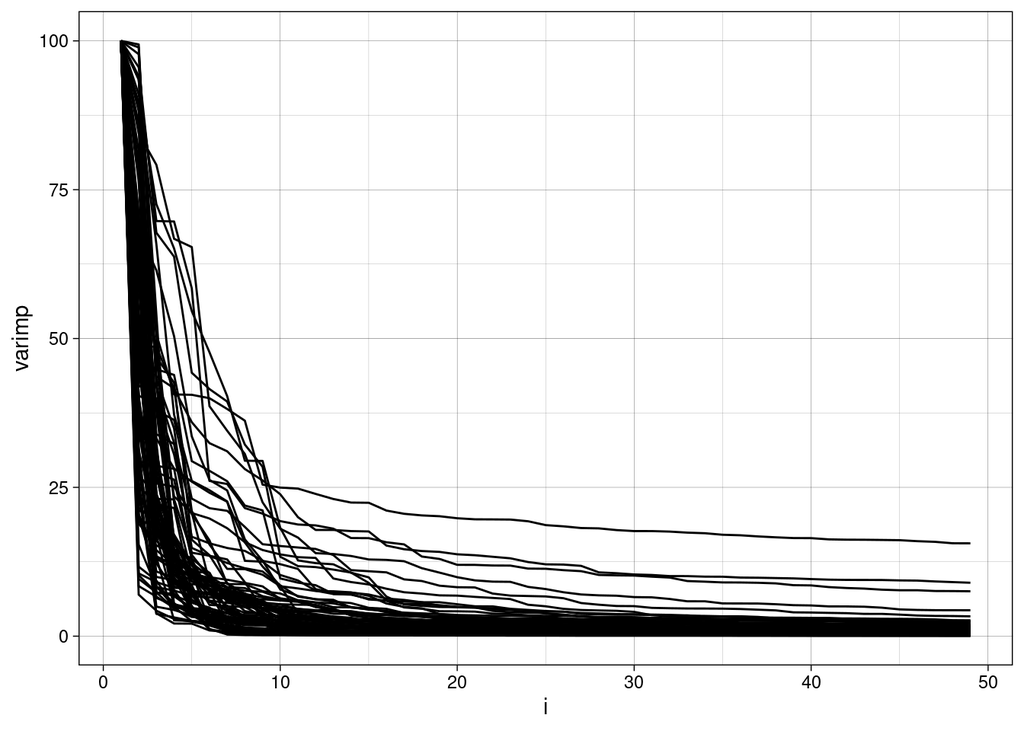

```r
var_imp <- fread("data/20220908101042.varimp.rf.txt")
setorder(var_imp, gene, -varimp)
var_imp[,i:=1:nrow(.SD), by=gene]

ggplot(var_imp[i<50], aes(i, varimp, group=gene)) +
  geom_line()
```

Plot network graph.

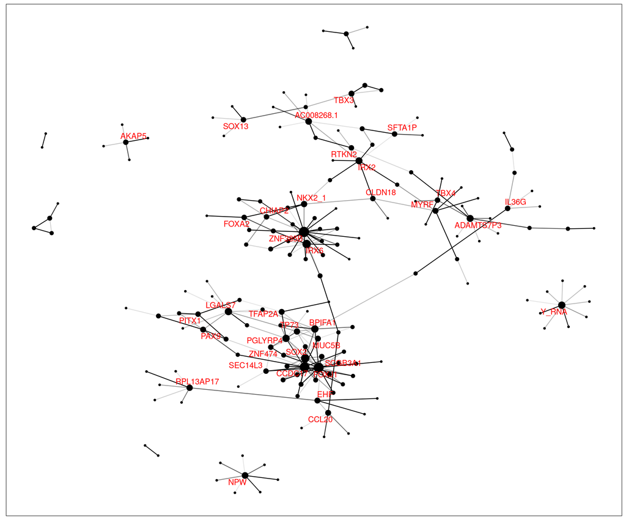

```r
require(tidygraph)
require(ggraph)
set.seed(1950)
varimp_top <- var_imp[varimp>25]

nodes <- data.frame(id = unique(c(varimp_top$Variable, varimp_top$gene)))
edges <- data.frame(from=varimp_top$Variable, to=varimp_top$gene, importance=varimp_top$varimp)

gp_tidy <- tbl_graph(nodes = nodes, edges = edges, directed = FALSE)  %>%
  mutate(centrality = centrality_degree(mode = 'in'))

ggraph(gp_tidy, layout = "graphopt") +
  geom_node_point(aes(size = centrality), show.legend = FALSE) +
  geom_edge_link(aes(alpha = importance), show.legend = FALSE) +
  scale_edge_width(range = c(0.2, 2)) +
  geom_node_text(aes(filter=centrality > 3, label = id), color="red", repel = TRUE)
```